# Evaluation of Definition Structure

J. Allen Baron

Created: 2022-04-06 Updated: 2022-06-28

# Purpose

To better understand the style of definitions used within the Human Disease Ontology, particularly with regard to “characterized by” statements.

# Background

The definition [style guide](https://docs.google.com/document/d/1YUv_7noj3JJIuSSECU3ufAbXvDiPTugIDv7Dm0mRypw) indicates that definitions should always begin with their parent term and a description of the disease’s etiology (cause).

Lynn has explained that definitions frequently use “characterized by”, but it’s not clear to me if this should preface the etiology or signs/symptoms, and “has_material_basis_in”, which as I understand it is only used when a genetic cause is identified.

```r
repo <- DOrepo("~/Documents/Ontologies/HumanDiseaseOntology")
q <- "
    PREFIX rdfs: <http://www.w3.org/2000/01/rdf-schema#>
    PREFIX owl: <http://www.w3.org/2002/07/owl#>
    PREFIX oio: <http://www.geneontology.org/formats/oboInOwl#>
    PREFIX IAO: <http://purl.obolibrary.org/obo/IAO_>

    SELECT ?id ?label ?obs ?def ?parent_label
    WHERE {
        ?c IAO:0000115 ?def ;
            oio:id ?id ;
            rdfs:label ?label;
            rdfs:subClassOf ?parent .
        ?parent rdfs:label ?parent_label .
        FILTER(CONTAINS(STR(?c), 'DOID'))
        FILTER(!ISBLANK(?parent))
        OPTIONAL { ?c owl:deprecated ?obs . }
    }"

def <- repo$doid$query(q) %>%
    tibble::as_tibble() %>%
    tidyr::unnest(obs, keep_empty = TRUE) %>%
    dplyr::mutate(
        obs = dplyr::if_else(is.na(obs), FALSE, obs),
        cb_format = stringr::str_extract(def, "(that is )?characterized by"),
        chr_by = stringr::str_extract(def, "characterized by.*") %>%
            stringr::str_squish()
    ) %>%
    dplyr::arrange(id)
```

# Questions and Analysis

## “characterized by”

1. How many definitions use “characterized by” and do the majority use the format “that is characterized by” or just “characterized by”?

```r
dplyr::count(def, obs, cb_format) %>%
    add_percent(n)
```

| obs | cb_format | n | pct |
| --- | --- | --- | --- |
| FALSE | characterized by | 3336 | 26.95 |
| FALSE | that is characterized by | 2741 | 22.14 |
| FALSE | NA | 6302 | 50.91 |

The “characterized by” statement appears in about 1/2 of the non-obsolete definitions, with both formats used equally.

2. Is there a difference in format based on when a term was created? *Newer terms can be identified by a leading “0”.*

```r
def <- def %>%
    dplyr::mutate(newer = stringr::str_detect(id, "DOID:0"))

def %>%
    dplyr::filter(!obs) %>%
    dplyr::count(newer, cb_format) %>%
    add_percent(n)
```

| newer | cb_format | n | pct |
| --- | --- | --- | --- |
| FALSE | characterized by | 444 | 3.59 |
| FALSE | that is characterized by | 1050 | 8.48 |
| FALSE | NA | 2574 | 20.79 |
| TRUE | characterized by | 2892 | 23.36 |
| TRUE | that is characterized by | 1691 | 13.66 |
| TRUE | NA | 3728 | 30.12 |

Newer IDs more often use “characterized by” without the “that is”.

**PREFER format without “that is”.**

3. What is the “characterized by” statement for?

```r
def %>%
    dplyr::filter(!is.na(chr_by)) %>%
    dplyr::select(chr_by)
```

| chr_by |
| --- |
| characterized by a triangular tissue growth located_in cornea of the eye that is the result of collagen degeneration and fibrovascular proliferation. |
| characterized by deterioration of the function of the heart muscle. |
| characterized by deterioration of the function of the heart muscle. |
| characterized by a build up of plaque in the arteries. |
| characterized by inflammation of the blood vessels. |
| characterized by blistered skin as a result of self-reactive T and B cells that target BP180. |
| characterized by hypoglycemia caused by antibodies to insulin. |
| characterized by back pain, perineal pain, pain with ejaculation, hematospermia and voiding symptoms resulting from inflammation located_in the seminal vesicles caused by Neisseria gonorrhoeae infecti… |
| characterized by abnormal mineral metabolism. |
| characterized by a cardiomyopathy secondary to selenium deficiency. |

[output cut: 990 more lines]

There is a mix of its use preceding a list of symptoms/phenotypes/signs and use preceding a cause. I’ll need to ask for clarification on the preference.

**The consensus is that “characterized by” should precede a list of symptoms/phenotypes/signs.**

4. Where does “characterized by” usually occur in a definition? Or, in other words, how many words precede “characterized by”?

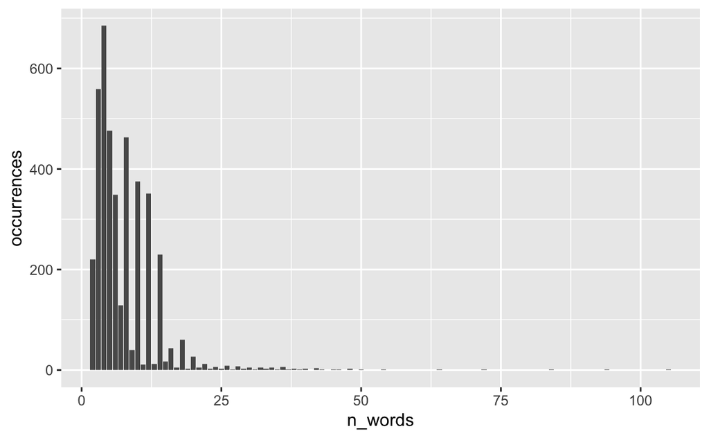

```r
def %>%
    dplyr::mutate(
        before_cb = stringr::str_extract(
            def,
            ".*?characterized by"
        ) %>%
            stringr::str_remove("(that is )characterized by")
    ) %>%
    dplyr::select(id, before_cb) %>%
    dplyr::filter(!is.na(before_cb)) %>%
    tidytext::unnest_tokens(
        output = "word",
        input = before_cb,
        token = "words"
    ) %>%
    dplyr::count(id, name = "n_words") %>%
    dplyr::count(n_words, name = "occurrences") %>%
    ggplot() +
    geom_col(aes(x = n_words, y = occurrences))
```

Most often the “characterized by” is the fourth or fifth word which means it’s generally at the beginning of a definition, probably right after the “A {parent}” statement.

**“characterized by” should generally be at the start of a definition.**

### Syndromes (and “characterized by”)

1. What about “characterized by” statements for syndromes?

```r
syndrome_q <- "
    PREFIX rdfs: <http://www.w3.org/2000/01/rdf-schema#>
    PREFIX owl: <http://www.w3.org/2002/07/owl#>
    PREFIX oio: <http://www.geneontology.org/formats/oboInOwl#>
    PREFIX IAO: <http://purl.obolibrary.org/obo/IAO_>
    PREFIX DOID: <http://purl.obolibrary.org/obo/DOID_>

    SELECT ?id ?label ?obs ?def
    WHERE {
        ?c IAO:0000115 ?def ;
            oio:id ?id ;
            rdfs:label ?label ;
            rdfs:subClassOf DOID:225 .
        OPTIONAL { ?c owl:deprecated ?obs . }
    }"

syn_def <- repo$doid$query(syndrome_q) %>%
    tibble::as_tibble() %>%
    tidyr::unnest(obs, keep_empty = TRUE) %>%
    dplyr::mutate(
        obs = dplyr::if_else(is.na(obs), FALSE, obs),
        cb_format = stringr::str_extract(def, "(that is )?characterized by"),
        chr_by = stringr::str_extract(def, "characterized by.*") %>%
            stringr::str_squish()
    ) %>%
    dplyr::arrange(id)
```

```r
count(syn_def, obs, cb_format)
```

| obs | cb_format | n |
| --- | --- | --- |
| FALSE | characterized by | 234 |
| FALSE | that is characterized by | 150 |
| FALSE | NA | 30 |

“characterized by” is *VERY* common for syndromes.

2. What about syndromes in name ONLY for which causes are known? *(i.e. those not in the syndrome branch of DO but with “syndrome” in their name)*

```r
def <- def %>%
    dplyr::mutate(
        syndrome_in_name = stringr::str_detect(label, "[Ss]yndrome"),
        true_syndrome = id %in% syn_def$id
    )

def %>%
    dplyr::filter(!obs) %>%
    dplyr::count(syndrome_in_name, true_syndrome) %>%
    add_percent(n)
```

| syndrome_in_name | true_syndrome | n | pct |
| --- | --- | --- | --- |
| FALSE | FALSE | 10412 | 84.11 |
| FALSE | TRUE | 148 | 1.20 |
| TRUE | FALSE | 1223 | 9.88 |
| TRUE | TRUE | 596 | 4.81 |

```r
sino <- def %>%
    dplyr::filter(syndrome_in_name, !true_syndrome, !obs)

sino %>%
    dplyr::count(cb_format) %>%
    add_percent(n)
```

| cb_format | n | pct |
| --- | --- | --- |
| characterized by | 379 | 30.99 |
| that is characterized by | 369 | 30.17 |
| NA | 475 | 38.84 |

Most still have “characterized by” in their definitions.

```r
sino %>%
    dplyr::select(def)
```

| def |
| --- |
| A dengue disease that involves the most severe form of dengue fever, has_material_basis_in Dengue virus [NCBITaxon:12637] with four serotypes (Dengue virus 1, 2, 3 and 4), which are transmitted_by Aed… |
| A primary ciliary dyskinesia that is characterized by sinusitis, bronchiectasis and situs inversus with dextrocardia resulting from dysfunction of the cilia during embryologic development. |
| An autoimmune polyendocrine syndrome that is inherited in an autosomal recessive fashion, which is characterized by abnormal functioning of the immune system that causes auto-reactivity against endocr… |
| An autoimmune polyendocrine syndrome that is characterized by abnormal functioning of the immune system that causes auto-reactivity against endocrine organs. It is more heterogeneous and has not been … |
| A neuromuscular junction disease that is characterized by an abnormality of acetylcholine (ACh) release at the neuromuscular junction which results from an autoimmune attack against voltage-gated calc… |
| A neuromuscular junction disease that is characterized by an abnormality of acetylcholine (ACh) release at the neuromuscular junction which results from an autoimmune attack against voltage-gated calc… |
| A neuromuscular junction disease that is characterized by an abnormality of acetylcholine (ACh) release at the neuromuscular junction which results from an autoimmune attack against voltage-gated calc… |
| A central nervous system disease characterized by throbbing, pulling creeping or other unpleasant sensations in the legs and the irresistible urge to move them. |
| A skin disease that is characterized by ulceration of less than 10 percent of the surface area of the body. The disease is often precipitated by the use of medications, such as antibiotics or antiepil… |
| An autism spectrum disorder that is characterized by significant difficulties in social interaction, along with restricted and repetitive patterns of behavior and interests. It differs from other auti… |

[output cut: 990 more lines]

It seems like “Budd-Chiari syndrome” (DOID:11512) really is a syndrome (no known cause). Maybe some of these should also be classified as syndromes?

3. How many syndromes *in name only* have causes identified?

```r
sino %>%
    dplyr::filter(stringr::str_detect(def, "from"))
```

| id | label | obs | def | parent_label | cb_format | chr_by | newer | syndrome_in_name | true_syndrome |
| --- | --- | --- | --- | --- | --- | --- | --- | --- | --- |
| DOID:0050144 | Kartagener syndrome | FALSE | A primary ciliary dyskinesia that is characterized by sinusitis, bronchiectasis and situs inversus with dextrocardia resulting from dysfunction of the cilia during embryologic development. | primary ciliary dyskinesia | that is characterized by | characterized by sinusitis, bronchiectasis and situs inversus with dextrocardia resulting from dysfunction of the cilia during embryologic development. | TRUE | TRUE | FALSE |
| DOID:0050214 | Lambert-Eaton myasthenic syndrome | FALSE | A neuromuscular junction disease that is characterized by an abnormality of acetylcholine (ACh) release at the neuromuscular junction which results from an autoimmune attack against voltage-gated calc… | autoimmune disease of peripheral nervous system | that is characterized by | characterized by an abnormality of acetylcholine (ACh) release at the neuromuscular junction which results from an autoimmune attack against voltage-gated calcium channels (VGCC) on the presynaptic mo… | TRUE | TRUE | FALSE |
| DOID:0050214 | Lambert-Eaton myasthenic syndrome | FALSE | A neuromuscular junction disease that is characterized by an abnormality of acetylcholine (ACh) release at the neuromuscular junction which results from an autoimmune attack against voltage-gated calc… | autoimmune disease of musculoskeletal system | that is characterized by | characterized by an abnormality of acetylcholine (ACh) release at the neuromuscular junction which results from an autoimmune attack against voltage-gated calcium channels (VGCC) on the presynaptic mo… | TRUE | TRUE | FALSE |
| DOID:0050214 | Lambert-Eaton myasthenic syndrome | FALSE | A neuromuscular junction disease that is characterized by an abnormality of acetylcholine (ACh) release at the neuromuscular junction which results from an autoimmune attack against voltage-gated calc… | neuromuscular junction disease | that is characterized by | characterized by an abnormality of acetylcholine (ACh) release at the neuromuscular junction which results from an autoimmune attack against voltage-gated calcium channels (VGCC) on the presynaptic mo… | TRUE | TRUE | FALSE |
| DOID:0050432 | Asperger syndrome | FALSE | An autism spectrum disorder that is characterized by significant difficulties in social interaction, along with restricted and repetitive patterns of behavior and interests. It differs from other auti… | autism spectrum disorder | that is characterized by | characterized by significant difficulties in social interaction, along with restricted and repetitive patterns of behavior and interests. It differs from other autism spectrum disorders by its relativ… | TRUE | TRUE | FALSE |
| DOID:0050450 | Gitelman syndrome | FALSE | A renal tubular transport disease that is has_material_basis_in mutations in genes that produce proteins involved in the kidneys' reabsorption of salt (sodium chloride or NaCl) from urine back into th… | autosomal recessive disease | NA | NA | TRUE | TRUE | FALSE |
| DOID:0050450 | Gitelman syndrome | FALSE | A renal tubular transport disease that is has_material_basis_in mutations in genes that produce proteins involved in the kidneys' reabsorption of salt (sodium chloride or NaCl) from urine back into th… | renal tubular transport disease | NA | NA | TRUE | TRUE | FALSE |
| DOID:0050693 | Brooke-Spiegler syndrome | FALSE | A skin disease that is characterized by the development of several types of tumors from the skin, has_material_basis_in heterozygous mutation in the CYLD gene on chromosome 16q12. | skin disease | that is characterized by | characterized by the development of several types of tumors from the skin, has_material_basis_in heterozygous mutation in the CYLD gene on chromosome 16q12. | TRUE | TRUE | FALSE |
| DOID:0050693 | Brooke-Spiegler syndrome | FALSE | A skin disease that is characterized by the development of several types of tumors from the skin, has_material_basis_in heterozygous mutation in the CYLD gene on chromosome 16q12. | autosomal dominant disease | that is characterized by | characterized by the development of several types of tumors from the skin, has_material_basis_in heterozygous mutation in the CYLD gene on chromosome 16q12. | TRUE | TRUE | FALSE |
| DOID:0050786 | iridogoniodysgenesis syndrome | FALSE | An iris disease that is characterized by the iris stroma being hypoplastic resulting from abnormalities in the differentiation of the anterior segment structures and increased values of intraocular pr… | autosomal dominant disease | that is characterized by | characterized by the iris stroma being hypoplastic resulting from abnormalities in the differentiation of the anterior segment structures and increased values of intraocular pressure and has_material_… | TRUE | TRUE | FALSE |

[output cut: 46 more lines]

About 38.

**Generally syndromes start with a “characterized by” list, which may be followed by the cause if known.**

## NOT “characterized by”

1. When would a “characterized by” statement be *inappropriate*?

```r
no_cb <- def %>%
    dplyr::filter(is.na(chr_by)) %>%
    dplyr::select(def)
no_cb
```

| def |
| --- |
| A vascular cancer that derives_from the cells that line the walls of blood vessels or lymphatic vessels. |
| A disease that involving errors in metabolic processes of building or degradation of molecules. |
| A crustacean allergy that has_allergic_trigger shrimp. |
| A drug allergy that has_allergic_trigger acetylsalicylic acid. |
| A beta-lactam allergy that has_allergic_trigger benzylpenicillin. |
| A beta-lactam allergy that has_allergic_trigger amoxicillin. |
| A cephalosporin allergy that has_allergic_trigger ceftriaxone. |
| A drug allergy that has_allergic_trigger carbamazepine. |
| A drug allergy that has_allergic_trigger abacavir. |
| A drug allergy that has_allergic_trigger isoniazide. |

[output cut: 990 more lines]

Allergies, autoimmune diseases, and infectious diseases do not appear to use “characterized by” statements.

2. When “characterized by” is absent, what follows the “parent” statement?

```r
no_cb <- def %>%
    dplyr::filter(is.na(chr_by)) %>%
    dplyr::mutate(
        after_parent = purrr::map2_chr(
            .x = def,
            .y = parent_label,
            ~ stringr::str_extract(.x, paste0(.y, ".*")) %>%
                stringr::str_remove(.y) %>%
                stringr::str_squish()
        )
    ) %>%
    dplyr::select(id, after_parent) %>%
    dplyr::filter(!is.na(after_parent))

no_cb_word <- no_cb %>%
    tidytext::unnest_tokens(
        output = "word",
        input = after_parent,
        token = "words"
    ) %>%
    dplyr::group_by(id) %>%
    dplyr::mutate(pos = dplyr::row_number()) %>%
    dplyr::ungroup() %>%
    dplyr::count(pos, word) %>%
    dplyr::arrange(pos, dplyr::desc(n)) %>%
    dplyr::group_by(pos) %>%
    dplyr::mutate(rank = dplyr::row_number(rev(n))) %>%
    dplyr::ungroup() %>%
    dplyr::filter(rank <= 10, pos < 4) %>%
    add_percent(n, pos)

no_cb_word %>%
    dplyr::filter(rank < 6) %>%
    dplyr::select(pos, word, pct) %>%
    tidyr::pivot_wider(
        names_from = pos,
        values_from = pct
    )
```

| word | 1 | 2 | 3 |
| --- | --- | --- | --- |
| that | 93.52 | NA | NA |
| which | 1.54 | NA | NA |
| located_in | 0.91 | NA | 13.50 |
| and | 0.86 | NA | NA |
| triggered | 0.83 | NA | NA |
| has_material_basis_in | NA | 52.79 | NA |
| is | NA | 21.15 | NA |
| involves | NA | 8.16 | NA |
| results_in | NA | 4.98 | NA |
| derives_from | NA | 3.86 | NA |

[output cut: 4 more lines]

It seems that aside from “characterized by” the other major statements are primarily attached with “that” and include: “has_material_basis_in” > “located_in” > “involves” > “results_in” > “derives_from”.

The patterns may be easier to view as 3-grams (the first 3 words as a set) where those with relationship terms (identifiable by the presence of an underscore) have all following words removed in order to collapse them together. I think it would also be worth including “characterized by” to find out where it fits in terms of use frequency.

```r
def %>%
    dplyr::mutate(
        after_parent = purrr::map2_chr(
            .x = def,
            .y = parent_label,
            ~ stringr::str_extract(.x, paste0(.y, ".*")) %>%
                stringr::str_remove(.y) %>%
                stringr::str_squish()
        )
    ) %>%
    dplyr::select(id, after_parent) %>%
    dplyr::filter(!is.na(after_parent)) %>%
    dplyr::mutate(
        after_parent = stringr::str_replace_all(
            after_parent,
            c(
                "located in" = "located_in",
                "results in" = "results_in",
                "(that is ?)characterized[ _]+by" = "characterized_by",
                "characterized by" = "characterized_by"
            )
        )
    ) %>%
    tidytext::unnest_ngrams(output = "three", input = after_parent, n = 3) %>%
    dplyr::mutate(
        three = stringr::str_replace(
            three,
            "(.*_[a-z]+).*",
            "\\1"
        )
    ) %>%
    dplyr::group_by(id) %>%
    dplyr::filter(dplyr::row_number() == 1) %>%
    dplyr::ungroup() %>%
    dplyr::count(three, sort = TRUE) %>%
    add_percent(n)
```

| three | n | pct |
| --- | --- | --- |
| characterized_by | 3693 | 45.99 |
| that has_material_basis_in | 1991 | 24.79 |
| that is located_in | 367 | 4.57 |
| that results_in | 259 | 3.23 |
| that derives_from | 143 | 1.78 |
| that is a | 116 | 1.44 |
| that has_allergic_trigger | 86 | 1.07 |
| that is characterized | 62 | 0.77 |
| located_in | 51 | 0.64 |
| that has_material_basis | 41 | 0.51 |

[output cut: 547 more lines]

Ultimately it seems like the most frequent statements (ranked) are as follows:

**characterized by >> has_material_basis_in >> located_in > results_in > derives_from > is a > has_allergic_trigger**

Some less frequently used statements use: involves > arises from > affects > composed of

3. What is included in the “is a” statement?

```r
no_cb %>%
    dplyr::mutate(
        is_a = stringr::str_extract(after_parent, "that is a ([^ ]+ ){2}") %>%
            stringr::str_remove("that is a ")
    ) %>%
    dplyr::filter(!is.na(is_a)) %>%
    dplyr::count(is_a, sort = TRUE)
```

| is_a | n |
| --- | --- |
| loss of | 25 |
| hemorrhagic fever, | 12 |
| benign tumor | 4 |
| sexually transmitted | 3 |
| polyp that | 2 |
| soft tissue | 2 |
| superficial fungal | 2 |
| type of | 2 |
| zoonotic infection | 2 |
| zoonotic infectious | 2 |

[output cut: 49 more lines]

It appears that it is primarily used in place of one of the more common statements.

**“that is a” should be avoided and used in only rare instances.**

## “caused by”

1. How are “caused by” statements used?

```r
def <- def %>%
    dplyr::mutate(
        caused = stringr::str_extract(def, "caused by.*") %>%
            stringr::str_squish(),
        has_caused = !is.na(caused)
    )

count(def, obs, has_caused) %>%
    add_percent(n)
```

| obs | has_caused | n | pct |
| --- | --- | --- | --- |
| FALSE | FALSE | 12016 | 97.07 |
| FALSE | TRUE | 363 | 2.93 |

```r
count(def, newer, has_caused) %>%
    add_percent(n)
```

| newer | has_caused | n | pct |
| --- | --- | --- | --- |
| FALSE | FALSE | 3809 | 30.77 |
| FALSE | TRUE | 259 | 2.09 |
| TRUE | FALSE | 8207 | 66.30 |
| TRUE | TRUE | 104 | 0.84 |

These statements are not common. They’re use has declined in non-obsolete, newer terms. I’ll ask for clarification to determine whether they should be avoided.

## Parentheses & Terminology

1. Should definitions include words in parentheses?

```r
def <- def %>%
    dplyr::mutate(
        has_paren = stringr::str_detect(def, "\\(\\w+"),
        paren_content = stringr::str_extract_all(def, "\\(.+?\\)") %>%
            purrr::map_chr(cast_to_string)
    )

dplyr::count(def, has_paren) %>%
    add_percent(n)
```

| has_paren | n | pct |
| --- | --- | --- |
| FALSE | 11427 | 92.31 |
| TRUE | 952 | 7.69 |

Most often they **do not** include parentheses but they do exist.

2. Are medical terms or their explanations included in parentheses?

Looking at content…

```r
dplyr::filter(def, has_paren) %>%
    dplyr::select(paren_content)
```

| paren_content |
| --- |
| (Amblyomma americanum) |
| (Ixodes scapularis)\|(Ixodes pacificus)\|(Ixodes ricinus) |
| (Amblyomma hebraeum and Amblyomma variegatum) |
| (Rhipicephalus pumilio and Rhipicephalus sanguineus)\|(usually single) |
| (Rhipicephalus sanguineus) |
| (Rhipicephalus sanguineus) |
| (Haemaphysalis concinna) |
| (Amblyomma cajennense) |
| (Dermacentor taiwanensis and Haemaphysalis flava) |
| (Amblyomma maculatum) |

[output cut: 942 more lines]

The first few are scientific genus species names and I know there are gene names. Quantifying those…

```r
dplyr::filter(def, has_paren) %>%
    dplyr::mutate(
        is_species = stringr::str_detect(def, "\\([A-Z][a-z]+ [a-z]+"),
        is_gene = stringr::str_detect(def, "\\([A-Z0-9]{3,}")
    ) %>%
    dplyr::summarize(
        species = sum(is_species),
        gene = sum(is_gene),
        other = sum(!is_gene & !is_species)
    )
```

| species | gene | other |
| --- | --- | --- |
| 41 | 445 | 466 |

Reviewing content that are not genes or species names…

```r
def %>%
    dplyr::mutate(
        is_species = stringr::str_detect(def, "\\([A-Z][a-z]+ [a-z]+"),
        is_gene = stringr::str_detect(def, "\\([A-Z0-9]{3,}")
    ) %>%
    dplyr::filter(has_paren, !is_species, !is_gene) %>%
    dplyr::select(paren_content)
```

| paren_content |
| --- |
| (e.g., pancreatic disease or Coeliac disease)\|(which work to alleviate constipation by drawing water into the bowels) |
| (hypermotility) |
| (BoNTA, B, E and F) |
| (touch)\|(smell) |
| (alveoli)\|(malaise)\|(called Velcro crackles) |
| (IgM) |
| (coenurus) |
| (coenurus) |
| (coenurus) |
| (surgery) |

[output cut: 456 more lines]

There **are** medical terms or their explanations in parentheses. There’s not a neat regular expression pattern to identify and quantify them, but the number relative to the total number of definitions is proportionally low suggesting a preference **not** to use them. But again, I’ll need to ask for clarification as all versions exist.

**The preference should be use of medical terms over layman’s terms but it is not a hard and fast rule.**

## Common N-grams

The goal here is to identify common usage among definitions irrespective of order to try identify all words/2-grams/3-grams that serve to delineate statements.

1. What are the top 20 words (excluding stop words)?

```r
word <- def %>%
    dplyr::select(id, def) %>%
    tidytext::unnest_tokens(
        output = "word",
        input = "def",
        token = "words"
    ) %>%
    dplyr::anti_join(tidytext::stop_words, by = "word")

word_count <- word %>%
    dplyr::count(word, name = "freq", sort = TRUE) %>%
    add_percent(freq)

word_count %>%
    dplyr::filter(dplyr::row_number() <= 20)
```

| word | freq | pct |
| --- | --- | --- |
| has_material_basis_in | 7302 | 3.85 |
| characterized | 6207 | 3.27 |
| chromosome | 5839 | 3.08 |
| mutation | 5795 | 3.05 |
| gene | 3875 | 2.04 |
| heterozygous | 3612 | 1.90 |
| homozygous | 2429 | 1.28 |
| disease | 2337 | 1.23 |
| compound | 1891 | 1.00 |
| syndrome | 1673 | 0.88 |

[output cut: 10 more lines]

Visualizing more results as a word cloud…

```r
word_count %>%
    dplyr::mutate(
        word = stringr::str_replace(
            word,
            "has_material_basis_in",
            "has_mat_basis"
        )
    ) %>%
    wordcloud2::wordcloud2(size = 0.5, fontWeight = "normal")
```

[interactive chart not shown]

2. What are the top 2-grams?

```r
g2 <- def %>%
    dplyr::select(id, def) %>%
    tidytext::unnest_ngrams(
        output = "ngram",
        input = "def",
        n = 2
    )

g2 <- g2 %>%
    dplyr::count(ngram, name = "freq", sort = TRUE) %>%
    add_percent(freq)

g2 %>%
    dplyr::filter(dplyr::row_number() <= 20)
```

| ngram | freq | pct |
| --- | --- | --- |
| characterized by | 6094 | 2.11 |
| that has_material_basis_in | 6000 | 2.08 |
| on chromosome | 5434 | 1.88 |
| mutation in | 5405 | 1.87 |
| in the | 5277 | 1.83 |
| that is | 4166 | 1.44 |
| heterozygous mutation | 3365 | 1.17 |
| is characterized | 2960 | 1.03 |
| gene on | 2958 | 1.03 |
| of the | 2667 | 0.92 |

[output cut: 10 more lines]

2. What are the top 3-grams?

```r
g3 <- def %>%
    dplyr::select(id, def) %>%
    tidytext::unnest_ngrams(
        output = "ngram",
        input = "def",
        n = 3
    )

g3 <- g3 %>%
    dplyr::count(ngram, name = "freq", sort = TRUE) %>%
    add_percent(freq)

g3 %>%
    dplyr::filter(dplyr::row_number() <= 20)
```

| ngram | freq | pct |
| --- | --- | --- |
| mutation in the | 3452 | 1.25 |
| heterozygous mutation in | 3342 | 1.21 |
| gene on chromosome | 2948 | 1.07 |
| is characterized by | 2875 | 1.04 |
| that is characterized | 2821 | 1.02 |
| that has_material_basis_in homozygous | 1986 | 0.72 |
| compound heterozygous mutation | 1823 | 0.66 |
| or compound heterozygous | 1758 | 0.64 |
| homozygous or compound | 1757 | 0.64 |
| has_material_basis_in homozygous or | 1660 | 0.60 |

[output cut: 10 more lines]

That apparently is not a very useful exercise.

## Genetic Information

Not all “has_material_basis_in” uses in definitions refer to a genetic basis and no one term or pattern exists to identify all of these. Most, if not all, can be matched with a search for words like mutation, gene, chromosome, etc. The breakdown of matches used to identify genetic “has_material_basis_in” definitions is as follows (with some definitions having multiple matches):

```r
tmp <- def %>%
    dplyr::select(id:def) %>%
    dplyr::mutate(
        genetic_basis = stringr::str_extract_all(
            def,
            "(mut|vari)ation|chromosom|inherit| gene |[0-9]+[pq][0-9]+"
        ) %>%
            purrr::map_chr(
                ~ stringr::str_replace_all(.x, "[0-9]+[pq][0-9]+", "chrom_loc") %>%
                    unique() %>%
                    sort() %>%
                    DO.utils::vctr_to_string(delim = " | ")
            )
    ) %>%
    dplyr::filter(
        stringr::str_detect(def, "material[ _]basis[ _]"),
        genetic_basis != ""
    )

tmp %>%
    dplyr::count(genetic_basis) %>%
    inflate_col_(genetic_basis) %>%
    dplyr::count(genetic_basis, wt = n, sort = TRUE)
```

| genetic_basis | n |
| --- | --- |
| mutation | 5919 |
| chromosom | 5761 |
| chrom_loc | 5215 |
| gene | 3426 |
| inherit | 871 |
| variation | 285 |

The most common patterns are as follows:

```r
hmbi <- tmp %>%
    dplyr::mutate(
        hmbi = stringr::str_remove(def, ".*basis[ _]in[ _]+"),
        # replace gene symbols with placeholder
        hmbi = stringr::str_replace_all(
            hmbi,
            c(" [A-Z0-9\\-]{3,}([ .,])" = " GENE_SYM\\1",
              " [X0-9]+[pq][0-9.]*([ .,])" = " CHROM_SYM\\1")
        )
    )
```

```r
words <- hmbi %>%
    dplyr::select(label, hmbi) %>%
    tidytext::unnest_tokens(hmbi, output = "words") %>%
    dplyr::group_by(label) %>%
    dplyr::mutate(pos = dplyr::row_number()) %>%
    dplyr::ungroup()

words %>%
    dplyr::group_by(pos, words) %>%
    dplyr::summarize(n = length(words)) %>%
    dplyr::mutate(
        rank = dplyr::row_number(dplyr::desc(n)),
        words = paste0(words, " (", n, ")")
    ) %>%
    dplyr::ungroup() %>%
    dplyr::arrange(pos, rank) %>%
    dplyr::select(-n) %>%
    tidyr::pivot_wider(id_cols = rank, names_from = pos, values_from = words)
```

| rank | 1 | 2 | 3 | 4 | 5 | 6 | 7 | 8 | 9 | 10 | 11 | 12 | 13 | 14 | 15 | 16 | 17 | 18 | 19 | 20 | 21 | 22 | 23 | 24 | 25 | 26 | 27 | 28 | 29 | … |
| --- | --- | --- | --- | --- | --- | --- | --- | --- | --- | --- | --- | --- | --- | --- | --- | --- | --- | --- | --- | --- | --- | --- | --- | --- | --- | --- | --- | --- | --- | --- |
| 1 | homozygous (1280) | mutation (1241) | in (1228) | gene_sym (966) | mutation (1018) | in (1038) | on (862) | chromosome (871) | chrom_sym (888) | in (597) | chromosome (440) | chrom_sym (459) | the (416) | heterozygous (431) | mutation (471) | on (508) | chromosome (510) | chrom_sym (520) | chromosome (504) | chrom_sym (508) | gene (230) | on (251) | chromosome (250) | chrom_sym (249) | chromosome (52) | chrom_sym (50) | the (28) | on (31) | chromosome (32) | … |
| 2 | heterozygous (870) | or (1002) | compound (939) | heterozygous (945) | gene_sym (753) | gene (743) | gene_sym (589) | on (610) | mutation (577) | chrom_sym (592) | mutation (421) | in (433) | compound (408) | gene_sym (410) | gene (414) | in (476) | gene_sym (447) | on (499) | the (251) | gene_sym (236) | chromosome (81) | chrom_sym (84) | gene (42) | on (51) | mutation (26) | in (29) | gene_sym (21) | in (28) | the (28) | … |
| 3 | mutation (660) | in (885) | the (833) | the (837) | gene (593) | on (510) | chromosome (523) | gene_sym (491) | chromosome (575) | on (421) | homozygous (417) | or (420) | chromosome (331) | chrom_sym (340) | chromosome (325) | chrom_sym (323) | mutation (252) | in (270) | gene (52) | on (79) | the (47) | gene_sym (42) | gene_sym (25) | gene (24) | the (25) | the (24) | chrom_sym (19) | gene_sym (25) | gene (21) | … |
| 4 | autosomal (214) | autosomal (151) | inheritance (210) | mutation (232) | on (428) | chromosome (414) | the (523) | chrom_sym (482) | gene (460) | heterozygous (257) | the (335) | on (328) | gene (299) | on (317) | compound (205) | heterozygous (216) | gene (63) | gene_sym (64) | gene_sym (46) | in (50) | gene_sym (34) | the (33) | the (25) | in (23) | in (18) | of (19) | chromosome (18) | the (25) | in (18) | … |
| 5 | variation (190) | recessive (123) | dominant (87) | of (193) | of (166) | gene_sym (263) | chrom_sym (404) | heterozygous (268) | on (110) | homozygous (162) | gene_sym (328) | gene_sym (298) | homozygous (204) | or (207) | gene_sym (106) | gene_sym (74) | the (63) | gene (32) | mutation (39) | the (33) | in (31) | gene (25) | in (21) | heterozygous (21) | gene_sym (16) | on (18) | gene (18) | chrom_sym (19) | mutation (18) | … |
| 6 | an (147) | dominant (91) | recessive (82) | chromosome (164) | region (155) | chrom_sym (156) | in (126) | the (122) | gene_sym (92) | chromosome (134) | chrom_sym (103) | chromosome (73) | mutation (137) | of (102) | in (75) | chromosome (55) | chrom_sym (46) | the (32) | in (36) | chromosome (27) | chrom_sym (23) | in (23) | of (19) | or (20) | homozygous (16) | or (18) | in (17) | mutation (16) | gene_sym (14) | … |
| 7 | a (101) | of (71) | mutation (74) | in (87) | in (100) | mutation (98) | gene (96) | gene (105) | the (66) | gene (75) | autosomal (70) | heterozygous (54) | chrom_sym (59) | in (88) | the (70) | the (51) | in (41) | mutation (31) | on (25) | gene (26) | mutation (21) | of (18) | chrom_sym (15) | the (18) | on (16) | chromosome (16) | mutation (17) | or (15) | and (9) | … |
| 8 | hemizygous (93) | heterozygous (70) | of (73) | region (62) | the (91) | the (89) | compound (43) | in (81) | in (61) | the (73) | on (63) | dominant (48) | gene_sym (44) | mutation (60) | on (51) | of (42) | on (38) | heterozygous (30) | chrom_sym (16) | mutation (19) | of (18) | chromosome (16) | heterozygous (14) | gene_sym (16) | of (15) | gene (16) | heterozygous (16) | heterozygous (14) | or (9) | … |
| 9 | mutations (71) | linked (32) | a (52) | on (42) | homozygous (60) | or (52) | mutation (41) | hemizygous (48) | encoding (26) | an (57) | in (49) | the (44) | heterozygous (43) | chromosome (44) | chrom_sym (38) | gene (33) | heterozygous (24) | chromosome (27) | heterozygous (14) | heterozygous (16) | on (16) | or (16) | compound (12) | of (16) | gene (14) | gene_sym (16) | of (15) | of (12) | association (7) | … |
| 10 | compound (62) | inheritance (17) | gene_sym (49) | gene (39) | heterozygous (58) | of (30) | variation (31) | mutation (31) | region (20) | gene_sym (44) | or (45) | gene (43) | on (42) | gene (38) | or (25) | mutation (28) | of (17) | of (19) | and (13) | of (16) | and (14) | mutation (14) | homozygous (12) | mutation (13) | or (11) | mutation (16) | compound (13) | and (10) | heterozygous (7) | … |

[output cut: 276 more lines]

```r
g3 <- hmbi %>%
    dplyr::select(label, hmbi) %>%
    tidytext::unnest_ngrams(hmbi, n = 3, output = "words", to_lower = FALSE) %>%
    dplyr::group_by(label) %>%
    dplyr::mutate(pos = dplyr::row_number()) %>%
    dplyr::ungroup()

dplyr::count(g3, words, sort = TRUE)
```

| words | n |
| --- | --- |
| on chromosome CHROM_SYM | 5269 |
| mutation in the | 3433 |
| heterozygous mutation in | 3333 |
| the GENE_SYM gene | 3157 |
| in the GENE_SYM | 3127 |
| gene on chromosome | 2919 |
| GENE_SYM gene on | 2772 |
| GENE_SYM on chromosome | 2002 |
| compound heterozygous mutation | 1821 |
| in GENE_SYM on | 1780 |

[output cut: 990 more lines]

The major pattern BY FAR is probably “has_material_basis_in mutation in the gene on chromosome .” It’s challenging to know how often gene names are included but it might be possible to measure how often the gene symbol appears without the gene name.

```r
hmbi %>%
    dplyr::mutate(
        gene_phrase = stringr::str_extract(
            hmbi,
            "([A-Za-z0-9._\\-,]+ ){0,3}genes?( [A-Za-z0-9._\\-,]+){0,3}"
        )
    ) %>%
    dplyr::count(gene_phrase, sort = TRUE) %>%
    dplyr::mutate(pct = round(n / sum(n) * 100, 2))
```

| gene_phrase | n | pct |
| --- | --- | --- |
| NA | 2717 | 41.91 |
| in the GENE_SYM gene on chromosome CHROM_SYM. | 2488 | 38.38 |
| in the GENE_SYM gene | 239 | 3.69 |
| in the GENE_SYM gene on chromosome CHROM_SYM | 73 | 1.13 |
| gene on chromosome CHROM_SYM. | 53 | 0.82 |
| in the GENE_SYM gene on chromosome CHROM_SYM, | 37 | 0.57 |
| of the GENE_SYM gene on chromosome CHROM_SYM. | 34 | 0.52 |
| gene | 16 | 0.25 |
| GENE_SYM and GENE_SYM genes | 6 | 0.09 |
| in the GENE_SYM gene which results_in short | 6 | 0.09 |

[output cut: 449 more lines]

```r
gene_id <- hmbi %>%
    dplyr::mutate(
        gene_id = stringr::str_extract(hmbi,"the.*gene|gene for .*")
    ) %>%
    dplyr::count(gene_id, sort = TRUE) %>%
    dplyr::mutate(pct = round(n / sum(n) * 100, 2))

gene_id
```

| gene_id | n | pct |
| --- | --- | --- |
| the GENE_SYM gene | 3008 | 46.40 |
| NA | 2794 | 43.10 |
| the gene | 164 | 2.53 |
| the GENE_SYM gene on chromosome CHROM_SYM or the GENE_SYM gene | 12 | 0.19 |
| the GENE_SYM and GENE_SYM gene | 11 | 0.17 |
| the GENE_SYM or GENE_SYM gene | 11 | 0.17 |
| the GENE_SYM gene on chromosome CHROM_SYM, sometimes in association with mutation in another gene | 10 | 0.15 |
| the GENE_SYM gene on chromosome CHROM_SYM, sometimes in association with mutations in other gene | 8 | 0.12 |
| the GENE_SYM gene on chromosome CHROM_SYM, sometimes in association with mutation in other gene | 7 | 0.11 |
| the myelin protein-zero gene | 6 | 0.09 |

[output cut: 254 more lines]

# Review and Fix?

## First Word

I was surprised that some of the words in the first position of definitions was anything other than “a” or “an”. I save that list here to review for later, as these are likely mistakes.

```r
def %>%
    dplyr::select(id, def) %>%
    tidytext::unnest_tokens(
        output = "word",
        input = def,
        token = "words"
    ) %>%
    dplyr::group_by(id) %>%
    dplyr::mutate(pos = dplyr::row_number()) %>%
    dplyr::ungroup() %>%
    dplyr::filter(pos == 1, !word %in% c("a", "an")) %>%
    dplyr::arrange(id) %>%
    dplyr::select(-pos)
```

| id | word |
| --- | --- |
| DOID:0050129 | secretory |
| DOID:0050130 | osmotic |
| DOID:0050131 | motility |
| DOID:0060193 | the |
| DOID:0060352 | kleefstra |
| DOID:0081084 | acute |
| DOID:0110214 | cleft |
| DOID:1099 | alpha |
| DOID:227 | ankylosis |
| DOID:8529 | ulcer |

[output cut: 3 more lines]